# Predicting Bikeshare Demand

Johnathan Clementi

11/19/2021

```r
knitr::opts_chunk$set(
    error = FALSE,
    message = FALSE,
    warning = FALSE,
    cache = TRUE
)
```

# 1. Introduction

[figure not shown]

In the past decade, cities such as New York, Chicago, and Philadelphia have welcomed the installation of docked bike-sharing systems which allow users to pay a small fee to rent a bicycle. As an alternative to vehicular transportation, bike-share allows riders the convenience of an agile and healthy way to get from point A to point B without needing to worry about maintenance costs or the possibility of their bike being stolen. The rider simply checks a bike out at a station, rides to their destination, and checks the bike in at another station. For operators of these systems, it is critical to ensure that bikes are balanced across the network of stations. If there are too few bikes at a station, ridership will decrease due to lack of bike supply. If there are too many bikes at a station, riders will be frustrated if they need to ride to a station further from their desired destination with more spaces and eventually stop using the service.  
For these reasons, it is imperative that bike-share systems rebalance bike supply based on rider demand. Systems have developed a few methods for addressing rebalancing. The first is utilizing trucks to move bikes to higher demand stations. The second is to incentivize users riding bikes to higher origin demand stations (stations that regularly have too few bikes) by giving those riders a credit for the service. How then, do system operators decide which stations need bikes and which stations can spare bikes? In this study, we examine how spatial and temporal forecasting can help systems answer this question. The system in question is Capital Bikeshare in Washington DC.  
The Capital Bikeshare (CaBi) is a successful bike sharing business located in Washington DC. It has been in business since 2010 and is currently operated by the bikeshare operator, Motivate, which also operates several other systems in the US. CaBi currently has over 630 stations and 5400 bikes, which have served an average of about 7622 riders daily in 2021.

```r
library(tidyverse)
library(tidycensus)
library(sf)
library(lubridate)
library(tigris)
library(gganimate)
library(gifski)
library(riem)
library(gridExtra)
library(knitr)
library(kableExtra)
library(rmdformats)
library(FNN)
library(caret)


options(tigris_class = "sf")
source("https://raw.githubusercontent.com/urbanSpatial/Public-Policy-Analytics-Landing/master/functions.r")

palette5 <- c("#eff3ff","#bdd7e7","#6baed6","#3182bd","#08519c")
palette4 <- c("#D2FBD4","#92BCAB","#527D82","#123F5A")
palette2 <- c("#6baed6","#08519c")
```

# 2. Data Wrangling

Capital Bikeshare ride data obtained from this [link](https://s3.amazonaws.com/capitalbikeshare-data/index.html)  
More information about these data can be found at this [link](https://www.capitalbikeshare.com/system-data)

### 2.1. Capital Bikeshare Data

In the code chunks below, we clean the data for use. Code is hidden for ease of readability, but you can reveal the code by hitting the `code` button on the right.

```r
rides <- rbind(#read.csv(file.path(root.dir,"202108-capitalbikeshare-tripdata.csv")),
              read.csv(file.path(root.dir,"202109-capitalbikeshare-tripdata.csv")),
              read.csv(file.path(root.dir,"202110-capitalbikeshare-tripdata.csv"))
              )

rides <- rides %>%
  mutate(started_at = ymd_hms(started_at),
         ended_at = ymd_hms(ended_at),
         interval60 = floor_date(ymd_hms(started_at), unit = "hour"),
         interval15 = floor_date(ymd_hms(started_at), unit = "15 mins"),
         week = week(interval60),
         dotw = wday(interval60, label=TRUE)
        ) %>%
  mutate(weekend = ifelse(dotw %in% c("Sun", "Sat"), "Weekend", "Weekday")) %>%
  mutate(time_of_day = case_when(hour(interval60) < 7 | hour(interval60) > 18 ~ "Overnight",
                                 hour(interval60) >= 7 & hour(interval60) < 10 ~ "AM Rush",
                                 hour(interval60) >= 10 & hour(interval60) < 15 ~ "Mid-Day",
                                 hour(interval60) >= 15 & hour(interval60) <= 18 ~ "PM Rush")
        ) %>%
  filter(start_station_name != "Arizona Ave & MacArthur Blvd NW")
```

```r
# total pop - B25026_001E
tractsDC <- get_acs(geography = "tract",
                     variables = c("B01003_001", "B19013_001",
                                  "B02001_002", "B08013_001",
                                  "B08012_001", "B08301_001",
                                  "B08301_010", "B01002_001"),
                     year=2017,
                     state=11999,
                     geometry=TRUE,
                     output="wide") %>%
  st_transform(crs = crs) %>%
  rename(Total_Pop =  B01003_001E,
         Med_Inc = B19013_001E,
         Med_Age = B01002_001E,
         White_Pop = B02001_002E,
         Travel_Time = B08013_001E,
         Num_Commuters = B08012_001E,
         Means_of_Transport = B08301_001E,
         Total_Public_Trans = B08301_010E) %>%
  select(Total_Pop, Med_Inc, White_Pop, Travel_Time,
         Means_of_Transport, Total_Public_Trans,
         Med_Age,
         GEOID, geometry) %>%
  mutate(Percent_White = White_Pop / Total_Pop,
         Mean_Commute_Time = Travel_Time / Total_Public_Trans,
         Percent_Taking_Public_Trans = Total_Public_Trans / Means_of_Transport) %>%
  mutate(natMall = case_when(GEOID == "11001006202" ~ 1,
                             GEOID != "11001006202" ~ 0))


rides_tracts <- st_join(rides %>%
          filter(is.na(start_lng) == FALSE &
                   is.na(start_lat) == FALSE &
                   is.na(end_lat) == FALSE &
                   is.na(end_lng) == FALSE) %>%
          st_as_sf(., coords = c("start_lng", "start_lat"), crs = 4326),
        tractsDC %>%
          st_transform(crs=4326),
        join=st_intersects,
              left = TRUE) %>%
  rename(Origin.Tract = GEOID) %>%
  mutate(start_lng = unlist(map(geometry, 1)),
         start_lat = unlist(map(geometry, 2)))%>%
  as.data.frame() %>%
  select(-geometry)%>%
  st_as_sf(., coords = c("end_lng", "end_lat"), crs = 4326) %>%
  st_join(., tractsDC %>%
            st_transform(crs=4326),
          join=st_intersects,
          left = TRUE) %>%
  rename(Destination.Tract = GEOID)  %>%
  mutate(end_lng = unlist(map(geometry, 1)),
         end_lat = unlist(map(geometry, 2)))%>%
  as.data.frame() %>%
  select(-geometry)
```

```r
colleges <- st_read("https://opendata.arcgis.com/datasets/0d7bedf9d582472e9ff7a6874589b545_0.geojson") %>%
  st_transform(crs = crs)

# Help doc for this code: https://www.py4u.net/discuss/871336
colleges$indicator <- st_intersects(colleges, tractsDC) %>% lengths > 0

colleges <- colleges %>%
  filter(indicator == TRUE) %>%
  select(-indicator)
```

```r
# Retrieve location data for Capital Bikeshare dock locations
# Remove regions except for Washington DC because we don't have the computational resources for analyzing the entire population of bikeshare locations
# Why do station_id's not match up?????
docks <- st_read("https://opendata.arcgis.com/datasets/a1f7acf65795451d89f0a38565a975b3_5.geojson") %>%
  st_transform(crs) %>%
  dplyr::select(OBJECTID, LATITUDE, LONGITUDE, NAME, CAPACITY, REGION_NAME) %>%
  filter(REGION_NAME == "Washington, DC") %>%
  mutate(nn_college = nn_function(st_coordinates(.), st_coordinates(colleges), 1))

docks_Geom <- docks %>%
  as.data.frame() %>%
  distinct(NAME, .keep_all = TRUE) %>%
  select(NAME, geometry) %>%
  st_sf
```

```r
rides <- dplyr::left_join(rides, docks %>% st_drop_geometry(), by =c("start_station_name" = "NAME")) %>%
            select(-LONGITUDE, - LATITUDE, -OBJECTID, -REGION_NAME) %>%
            rename(start_station_capacity = CAPACITY,
                   start_station_nnCollege = nn_college) %>%
            na.omit()

rides <- dplyr::left_join(rides, docks %>% st_drop_geometry(), by =c("end_station_name" = "NAME")) %>%
            select(-LONGITUDE, - LATITUDE, -OBJECTID) %>%
            rename(end_station_capacity = CAPACITY,
                   end_station_nnCollege = nn_college) %>%
            na.omit()


# rides_tracts <- dplyr::left_join(rides_tracts, docks %>% st_drop_geometry(), by =c("start_station_name" = "NAME")) %>%
#             select(-LONGITUDE, - LATITUDE, -OBJECTID, -REGION_NAME) %>%
#             rename(start_station_capacity = CAPACITY,
#                    start_station_nnCollege = nn_college) %>%
#             na.omit()
#
# rides_tracts <- dplyr::left_join(rides_tracts, docks %>% st_drop_geometry(), by =c("end_station_name" = "NAME")) %>%
#             select(-LONGITUDE, - LATITUDE, -OBJECTID) %>%
#             rename(end_station_capacity = CAPACITY,
#                    end_station_nnCollege = nn_college) %>%
#             na.omit()
```

### 2.2 Weather Data

We hypothesize that weather is a driver of bikeshare. The idea is that undesirable precipitation, wind, and temperature will drive down ridership.

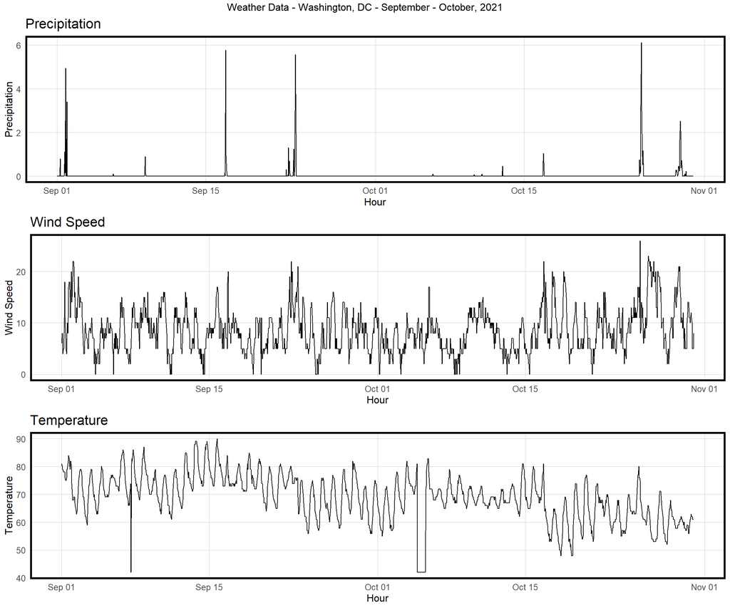

```r
# riem_networks <- riem_networks()
# vaStations <- riem_stations("VA_ASOS") %>%
#   st_as_sf(coords = c("lon","lat"), crs=crs)
# mdStations <- riem_stations("MD_ASOS") %>%
#   st_as_sf(coords = c("lon","lat"), crs=crs)
# The closest weather station to our study area is at Reagan National Airport - "DCA"

weather.Data <-
  riem_measures(station = "DCA", date_start = "2021-09-01", date_end = "2021-10-31")

weather.Panel <-
  weather.Data %>%
    mutate_if(is.character, list(~replace(as.character(.), is.na(.), "0"))) %>%
    replace(is.na(.), 0) %>%
    mutate(interval60 = ymd_h(substr(valid, 1, 13))) %>%
    mutate(week = week(interval60),
           dotw = wday(interval60, label=TRUE)) %>%
    group_by(interval60) %>%
    summarize(Temperature = max(tmpf),
              Precipitation = sum(p01i),
              Wind_Speed = max(sknt)) %>%
    mutate(Temperature = ifelse(Temperature == 0, 42, Temperature))

grid.arrange(top = "Weather Data - Washington, DC - September - October, 2021",
  ggplot(weather.Panel, aes(interval60, Precipitation)) + geom_line() +
    labs(title="Precipitation", x="Hour", y="Precipitation") + plotTheme(),
  ggplot(weather.Panel, aes(interval60,Wind_Speed)) + geom_line() +
    labs(title="Wind Speed", x="Hour", y="Wind Speed") + plotTheme(),
  ggplot(weather.Panel, aes(interval60,Temperature)) + geom_line() +
    labs(title="Temperature", x="Hour", y="Temperature") + plotTheme())
```

# 3. Ridership Visualizations

### 3.1. View ridership over time

In this first figure, we see that precipitation indeed drives ridership. Blue lines indicate hourly precipitaiton greater than 0.1 inches. Hourly ridership is visualized by the black line.

[figure not shown]

```r
precipHours <- weather.Panel %>%
  filter(Precipitation > 0.1) %>%
  mutate(precip = "Over0.1")

ggplot(rides %>%
       group_by(interval60) %>% tally())+
  geom_line(aes(x = interval60, y = n), size = 0.5) +
  geom_vline(data = precipHours, aes(xintercept = interval60), color = "blue", linetype = "dotted") +
  labs(title="Capital Bikeshare trips per hr. Washington, DC, September-October 2021",
       x="Date",
       y="Number of trips",
       caption = "Blue dotted lines indicate hours with more than 0.1 inches of precip.") +

  plotTheme()
```

The next two figures point out the temporal patterns in ridership. Many stations have high ridership in the PM Rush and do not have much ridership in the overnight hours.

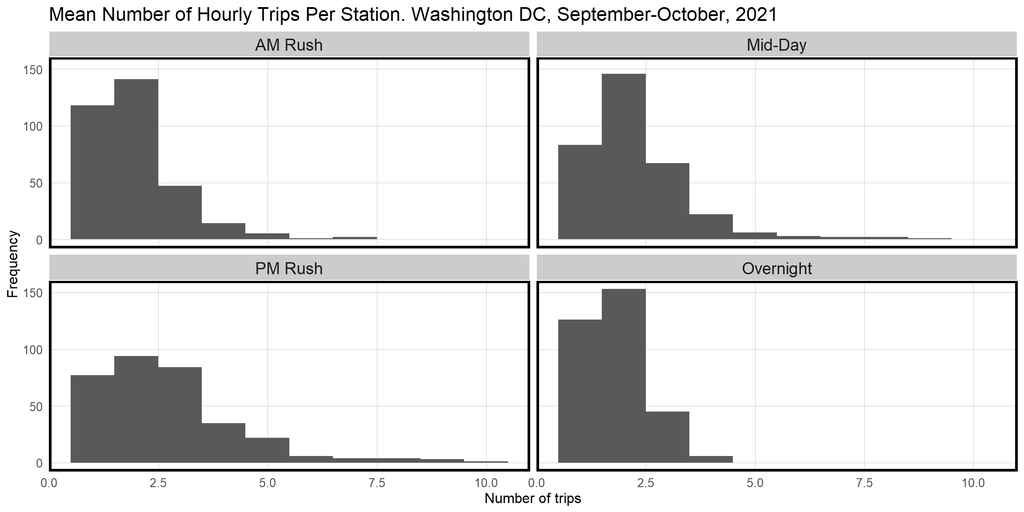

```r
rides %>%
  group_by(interval60, start_station_name, time_of_day) %>%
         tally() %>%
  filter(n < 25) %>%
  group_by(start_station_name, time_of_day) %>%
  summarize(mean_trips = mean(n)) %>%
  ggplot() +
    geom_histogram(aes(mean_trips), binwidth = 1)+
    labs(title="Mean Number of Hourly Trips Per Station. Washington DC, September-October, 2021",
         x="Number of trips",
         y="Frequency")+
    facet_wrap(~factor(time_of_day,levels=c("AM Rush", "Mid-Day", "PM Rush", "Overnight"))) +
  plotTheme()
```

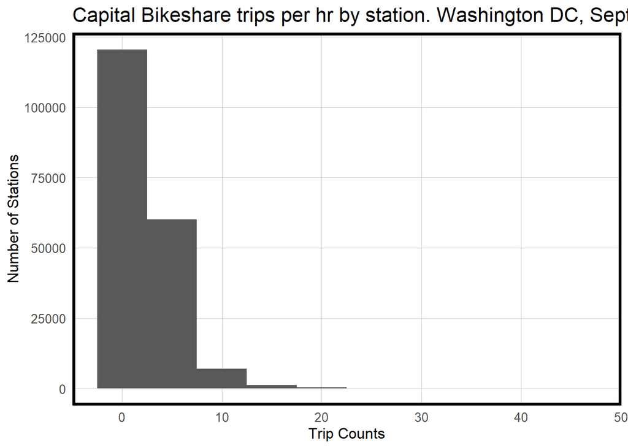

```r
ggplot(rides %>%
         group_by(interval60, start_station_name) %>%
         tally())+
  geom_histogram(aes(n), binwidth = 5)+
  labs(title="Capital Bikeshare trips per hr by station. Washington DC, September-October, 2021",
       x="Trip Counts",
       y="Number of Stations")+
  plotTheme()
```

The next two figures are particularly interesting because they point to the difference in CaBi rider demographics. We hypothesize that there are two general populations of CaBi riders: 1. the commuters, who drive the weekday peaks in the AM and PM rush hours. And 2. the tourists, who drive the weekend peak in the mid-day hours.

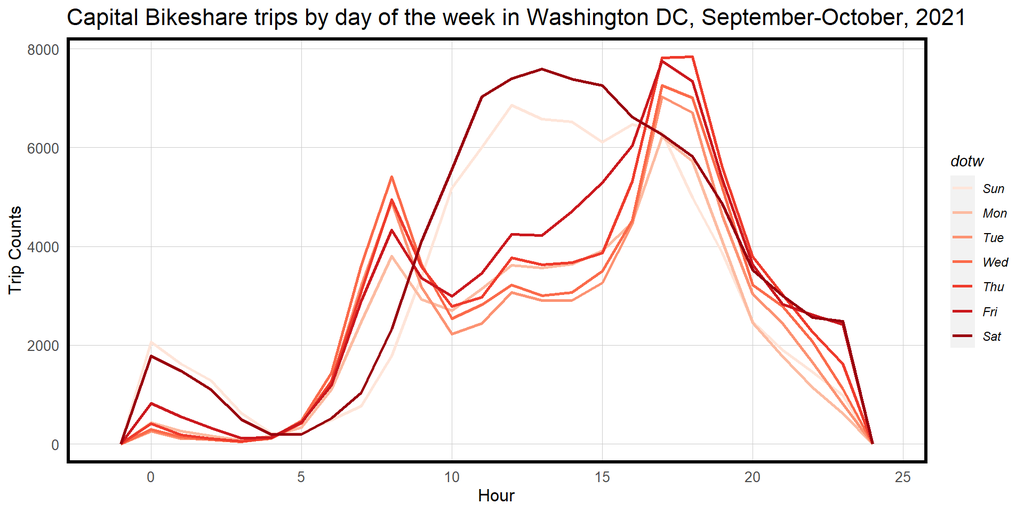

```r
ggplot(rides) +
  geom_freqpoly(aes(hour(started_at), color = dotw), size = 1, binwidth = 1) +
  scale_color_brewer(palette = "Reds") +
  labs(title="Capital Bikeshare trips by day of the week in Washington DC, September-October, 2021",
       x="Hour",
       y="Trip Counts") +
  plotTheme()
```

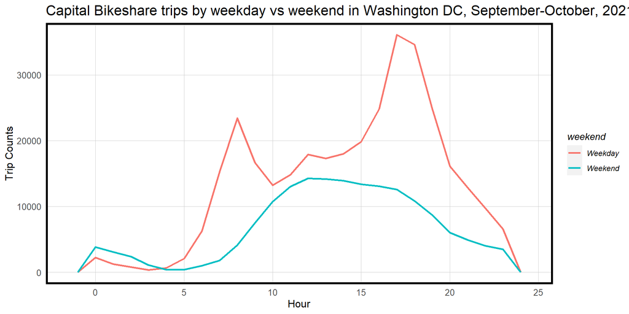

```r
ggplot(rides %>% mutate(weekend = ifelse(dotw %in% c("Sun", "Sat"), "Weekend", "Weekday"))) +
  geom_freqpoly(aes(hour(started_at), color = weekend), size = 1, binwidth = 1) +
  labs(title="Capital Bikeshare trips by weekday vs weekend in Washington DC, September-October, 2021",
       x="Hour",
       y="Trip Counts") +
  plotTheme()
```

Below are a series of maps illustrating the distribution of trip origins and destinations across the District.

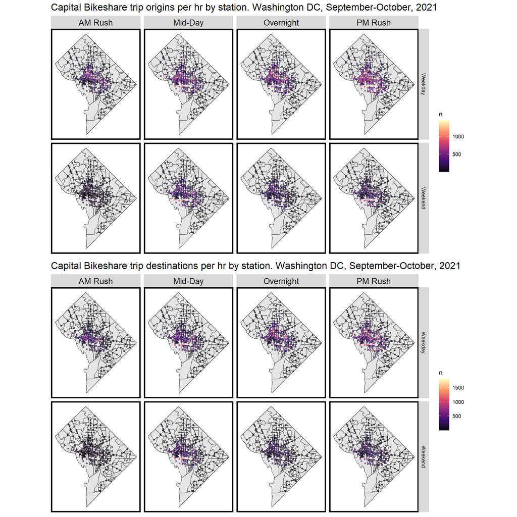

```r
grid.arrange(nrow = 2,
  ggplot()+
    geom_sf(data = tractsDC) +
    geom_sf(data = rides %>%
              group_by(start_station_id, start_station_name, weekend, time_of_day) %>%
              tally() %>%
              left_join(., docks, by =c("start_station_name" = "NAME")) %>%
              st_sf(),
            aes(color = n),
            fill = "transparent", alpha = 0.6, size = 1)+
    scale_colour_viridis_c(direction = 1, option = "magma")+
    # ylim(min(rides$start_lat), max(rides$start_lat))+
    # xlim(min(rides$start_lng), max(rides$start_lng))+
    facet_grid(weekend ~ time_of_day)+
    labs(title="Capital Bikeshare trip origins per hr by station. Washington DC, September-October, 2021") +
    mapTheme(),
  ggplot()+
    geom_sf(data = tractsDC) +
    geom_sf(data = rides %>%
              group_by(end_station_id, end_station_name, weekend, time_of_day) %>%
              tally() %>%
              left_join(., docks, by =c("end_station_name" = "NAME")) %>%
              st_sf(),
            aes(color = n),
            fill = "transparent", alpha = 0.6, size = 1)+
    scale_colour_viridis_c(direction = 1, option = "magma")+
    # ylim(min(rides$start_lat), max(rides$start_lat))+
    # xlim(min(rides$start_lng), max(rides$start_lng))+
    facet_grid(weekend ~ time_of_day)+
    labs(title="Capital Bikeshare trip destinations per hr by station. Washington DC, September-October, 2021") +
    mapTheme()
)
```

This animation is a great way to visualize the temporal distribution of ridership. It’s clear that most trips are originating from DC’s core around the National Mall and the business district that extends northward.

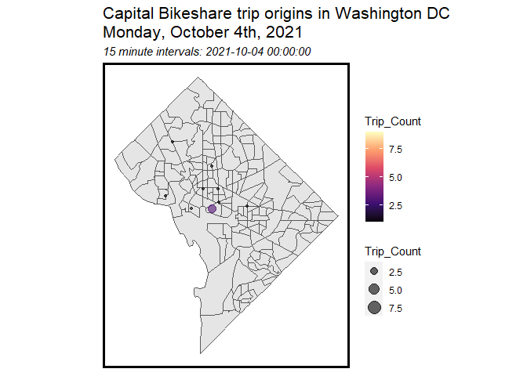

```r
rides.animation.df <- rides %>%
  filter(week == 40 & dotw == "Mon") %>%
  mutate(Trip_Counter = 1) %>%
  group_by(interval15, start_station_id, start_station_name) %>%
  summarize(Trip_Count = sum(Trip_Counter, na.rm=T)) %>%
  left_join(., docks, by =c("start_station_name" = "NAME")) %>%
  st_sf() %>%
  ungroup() %>%
  mutate(Trips = case_when(Trip_Count == 0 ~ "0 trips",
          Trip_Count > 0 & Trip_Count <= 3 ~ "1-3 trips",
          Trip_Count > 3 & Trip_Count <= 6 ~ "4-6 trips",
          Trip_Count > 6 & Trip_Count <= 10 ~ "7-10 trips",
          Trip_Count > 10 ~ "11+ trips")) %>%
  mutate(Trips  = fct_relevel(Trips, "0 trips","1-3 trips","4-6 trips",
  "7-10 trips","10+ trips")) %>%
  arrange(Trips)

ride_animation <-
  ggplot()+
  geom_sf(data = tractsDC) +
  geom_point(data = rides.animation.df,
          aes(color=Trip_Count, size = Trip_Count, geometry = geometry),
          stat = "sf_coordinates",
          fill = "transparent", alpha = 0.6)+
  scale_colour_viridis_c(direction = 1, option = "magma")+
  # ylim(min(rides$start_lat), max(rides$start_lat))+
  # xlim(min(rides$start_lng), max(rides$start_lng))+
  labs(title="Capital Bikeshare trip origins in Washington DC\nMonday, October 4th, 2021",
       subtitle = "15 minute intervals: {current_frame}") +
  mapTheme() +
  transition_manual(interval15)

animate(ride_animation, duration=20, renderer = gifski_renderer())
```

# 4. Analysis

### 4.1. Create space/time panel

```r
# length(unique(rides$interval60)) * length(unique(rides$start_station_id))

study.panel <-
  expand.grid(interval60 = unique(rides$interval60),
              start_station = unique(rides$start_station_id)) %>%
  left_join(., rides %>%
              select(start_station_id, start_station_name, start_lng, start_lat) %>%
              distinct() %>%
              group_by(start_station_id) %>%
              slice(1), by = c("start_station" = "start_station_id"))

# nrow(study.panel)

ride.panel <- rides %>%
  mutate(Trip_Counter = 1) %>%
  right_join(study.panel) %>%
  group_by(interval60, start_station_id, start_station_name, start_lng, start_lat) %>%
  summarize(Trip_Count = sum(Trip_Counter, na.rm=T)) %>%
  left_join(weather.Panel) %>%
  ungroup() %>%
  filter(is.na(start_station_id) == FALSE) %>%
  mutate(week = week(interval60),
         dotw = wday(interval60, label = TRUE))

# ride.panel <-
#   left_join(ride.panel, rides_tracts %>%
#               as.data.frame(), by = c("Origin.Tract" = "GEOID"))
```

### 4.2. Create Time Lags

```r
ride.panel <- ride.panel %>%
  arrange(start_station_id, interval60) %>%
  mutate(lagHour = dplyr::lag(Trip_Count,1),
         lag2Hours = dplyr::lag(Trip_Count,2),
         lag3Hours = dplyr::lag(Trip_Count,3),
         lag4Hours = dplyr::lag(Trip_Count,4),
         lag12Hours = dplyr::lag(Trip_Count,12),
         lag1day = dplyr::lag(Trip_Count,24)) %>%
  mutate(day = yday(interval60))
```

```r
as.data.frame(ride.panel) %>%
    group_by(interval60) %>%
    summarise_at(vars(starts_with("lag"), "Trip_Count"), mean, na.rm = TRUE) %>%
    gather(Variable, Value, -interval60, -Trip_Count) %>%
    mutate(Variable = factor(Variable, levels=c("lagHour","lag2Hours","lag3Hours","lag4Hours",
                                                "lag12Hours","lag1day")))%>%
    group_by(Variable) %>%
    summarize(correlation = round(cor(Value, Trip_Count),2))
```

```
## # A tibble: 6 x 2
##   Variable   correlation
##   <fct>            <dbl>
## 1 lagHour           0.76
## 2 lag2Hours         0.39
## 3 lag3Hours         0.07
## 4 lag4Hours        -0.17
## 5 lag12Hours       -0.01
## 6 lag1day          -0.32
```

## 4.3. Run Models

```r
ride.Train <- filter(ride.panel, (week >= 35) & (week <= 40))
ride.Test <- filter(ride.panel, week >= 41)

# Remove stops that are in test or train, but not in the other
removeList <- rbind(anti_join(ride.Train, ride.Test, by = "start_station_name"),
                    anti_join(ride.Test, ride.Train, by = "start_station_name")) %>%
              select(start_station_name)

removeList <- unique(removeList$start_station_name)

ride.Train <- ride.Train[!ride.Train$start_station_name %in% removeList,]
ride.Test <- ride.Test[!ride.Test$start_station_name %in% removeList,]
```

```r
# Temporal Only
reg1 <- lm(Trip_Count ~  hour(interval60) , data=ride.Train)
summary(reg1)
```

```
##
## Call:
## lm(formula = Trip_Count ~ hour(interval60), data = ride.Train)
##
## Residuals:
##    Min     1Q Median     3Q    Max
## -1.962 -1.500 -0.710  0.583 34.458
##
## Coefficients:
##                  Estimate Std. Error t value Pr(>|t|)
## (Intercept)       1.99708    0.01950  102.43   <2e-16 ***
## hour(interval60)  0.04195    0.00132   31.78   <2e-16 ***
## ---
## Signif. codes:  0 '***' 0.001 '**' 0.01 '*' 0.05 '.' 0.1 ' ' 1
##
## Residual standard error: 2.275 on 101435 degrees of freedom
## Multiple R-squared:  0.009859,   Adjusted R-squared:  0.00985
## F-statistic:  1010 on 1 and 101435 DF,  p-value: < 2.2e-16
```

```r
# Spatial only
reg2 <- lm(Trip_Count ~  start_station_id + Temperature + Precipitation + Wind_Speed, data=ride.Train)
summary(reg2)
```

```
##
## Call:
## lm(formula = Trip_Count ~ start_station_id + Temperature + Precipitation +
##     Wind_Speed, data = ride.Train)
##
## Residuals:
##    Min     1Q Median     3Q    Max
## -2.088 -1.517 -0.685  0.571 34.497
##
## Coefficients:
##                    Estimate Std. Error t value Pr(>|t|)
## (Intercept)       2.639e+01  1.162e+00  22.719  < 2e-16 ***
## start_station_id -7.925e-04  3.695e-05 -21.449  < 2e-16 ***
## Temperature       1.379e-02  9.517e-04  14.487  < 2e-16 ***
## Precipitation    -2.409e-01  2.011e-02 -11.983  < 2e-16 ***
## Wind_Speed        6.144e-03  2.125e-03   2.891  0.00384 **
## ---
## Signif. codes:  0 '***' 0.001 '**' 0.01 '*' 0.05 '.' 0.1 ' ' 1
##
## Residual standard error: 2.276 on 101432 degrees of freedom
## Multiple R-squared:  0.008932,   Adjusted R-squared:  0.008892
## F-statistic: 228.5 on 4 and 101432 DF,  p-value: < 2.2e-16
```

```r
# spatiotemporal
reg3 <- lm(Trip_Count ~  start_station_id + hour(interval60) + dotw + Temperature + Precipitation + Wind_Speed, data=ride.Train)
summary(reg3)
```

```
##
## Call:
## lm(formula = Trip_Count ~ start_station_id + hour(interval60) +
##     dotw + Temperature + Precipitation + Wind_Speed, data = ride.Train)
##
## Residuals:
##    Min     1Q Median     3Q    Max
## -2.612 -1.418 -0.719  0.635 34.048
##
## Coefficients:
##                    Estimate Std. Error t value Pr(>|t|)
## (Intercept)       2.617e+01  1.152e+00  22.716  < 2e-16 ***
## start_station_id -7.822e-04  3.664e-05 -21.348  < 2e-16 ***
## hour(interval60)  3.730e-02  1.552e-03  24.033  < 2e-16 ***
## dotw.L            2.244e-01  1.925e-02  11.659  < 2e-16 ***
## dotw.Q            5.598e-01  1.920e-02  29.163  < 2e-16 ***
## dotw.C            3.352e-02  1.967e-02   1.704  0.08833 .
## dotw^4            1.064e-02  1.903e-02   0.559  0.57628
## dotw^5           -5.290e-02  1.892e-02  -2.796  0.00518 **
## dotw^6            9.334e-02  1.903e-02   4.904 9.39e-07 ***
## Temperature       4.590e-03  1.051e-03   4.369 1.25e-05 ***
## Precipitation    -2.110e-01  2.013e-02 -10.485  < 2e-16 ***
## Wind_Speed        1.168e-02  2.336e-03   5.002 5.69e-07 ***
## ---
## Signif. codes:  0 '***' 0.001 '**' 0.01 '*' 0.05 '.' 0.1 ' ' 1
##
## Residual standard error: 2.257 on 101425 degrees of freedom
## Multiple R-squared:  0.02561,    Adjusted R-squared:  0.0255
## F-statistic: 242.3 on 11 and 101425 DF,  p-value: < 2.2e-16
```

```r
#spatiotemporal with lags
reg4 <- lm(Trip_Count ~  start_station_id +  hour(interval60) + dotw + Temperature + Precipitation + Wind_Speed +lagHour + lag2Hours + lag3Hours + lag1day, data=ride.Train)
summary(reg4)
```

```
##
## Call:
## lm(formula = Trip_Count ~ start_station_id + hour(interval60) +
##     dotw + Temperature + Precipitation + Wind_Speed + lagHour +
##     lag2Hours + lag3Hours + lag1day, data = ride.Train)
##
## Residuals:
##      Min       1Q   Median       3Q      Max
## -14.0403  -1.1288  -0.5762   0.6582  29.1636
##
## Coefficients:
##                    Estimate Std. Error t value Pr(>|t|)
## (Intercept)       1.180e+01  1.054e+00  11.201  < 2e-16 ***
## start_station_id -3.490e-04  3.348e-05 -10.423  < 2e-16 ***
## hour(interval60)  5.726e-03  1.434e-03   3.994 6.51e-05 ***
## dotw.L            1.597e-01  1.757e-02   9.091  < 2e-16 ***
## dotw.Q            2.516e-01  1.760e-02  14.293  < 2e-16 ***
## dotw.C            5.418e-03  1.788e-02   0.303  0.76189
## dotw^4           -1.514e-02  1.730e-02  -0.875  0.38139
## dotw^5           -2.997e-02  1.720e-02  -1.742  0.08148 .
## dotw^6            4.680e-02  1.730e-02   2.705  0.00683 **
## Temperature       2.263e-03  9.551e-04   2.369  0.01782 *
## Precipitation    -9.313e-02  1.832e-02  -5.083 3.72e-07 ***
## Wind_Speed        4.934e-03  2.124e-03   2.323  0.02017 *
## lagHour           3.213e-01  3.147e-03 102.084  < 2e-16 ***
## lag2Hours         1.239e-01  3.289e-03  37.662  < 2e-16 ***
## lag3Hours         5.652e-02  3.159e-03  17.892  < 2e-16 ***
## lag1day           5.651e-02  2.860e-03  19.755  < 2e-16 ***
## ---
## Signif. codes:  0 '***' 0.001 '**' 0.01 '*' 0.05 '.' 0.1 ' ' 1
##
## Residual standard error: 2.051 on 101397 degrees of freedom
##   (24 observations deleted due to missingness)
## Multiple R-squared:  0.1956, Adjusted R-squared:  0.1954
## F-statistic:  1643 on 15 and 101397 DF,  p-value: < 2.2e-16
```